# latent_space_model

# Statistical models for network visualization

## The MDS

```r
library(sna)
library(VBLPCM)
data(sampson)

A = as.matrix.network.adjacency(samplike)
```

Once we have the network loaded, we first need to compute the shortest-path distance on the graph.

```r
g = as.network(A)
D = dist(g)
```

Here the `dist` function recognizes the object `g` is a network and the shortest-path distance is computed.

The MDS algorithm is implemented in R by the “cmdscale” function:

```r
?comdscale
```

```
## No documentation for 'comdscale' in specified packages and libraries:
## you could try '??comdscale'
```

A call to MDS will be:

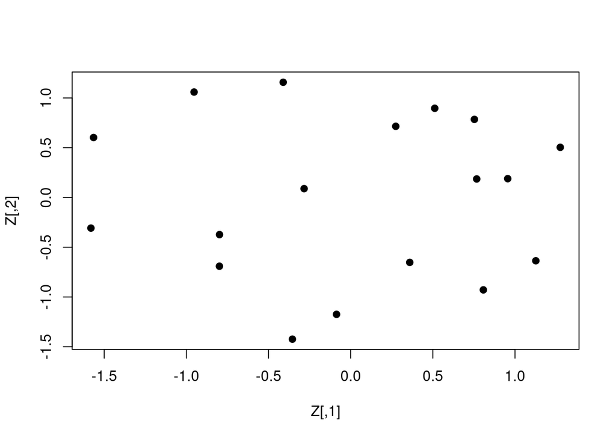

```r
Z = cmdscale(D,2)
plot(Z,pch=19)
```

If we want to also plot the edges, we can use the gplot function of the same package:

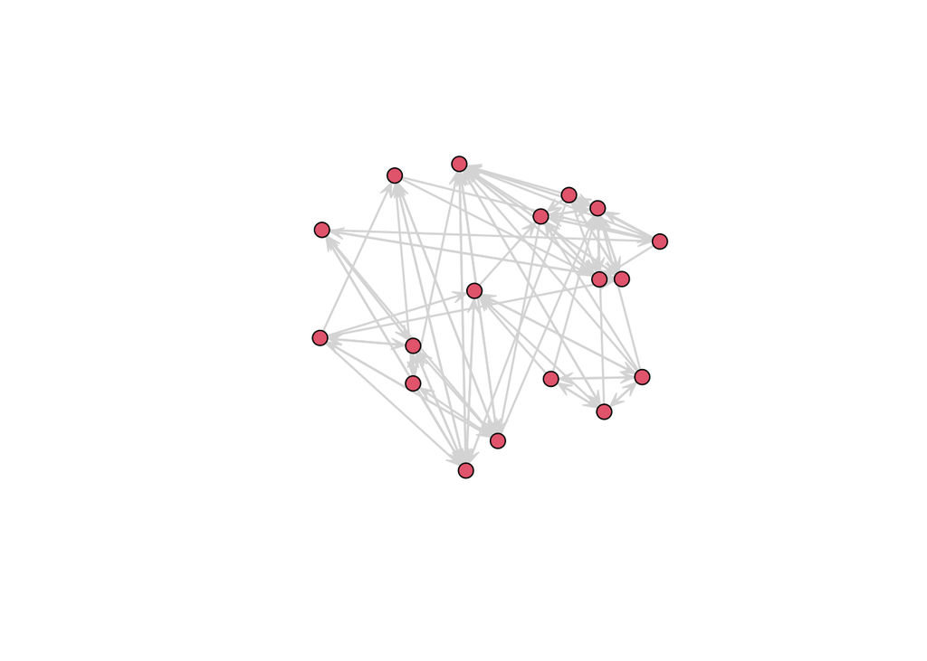

```r
library(sna)
gplot(A, coord=Z, edge.col="lightgray")
```

It is also interesting to come back to a very simple network.

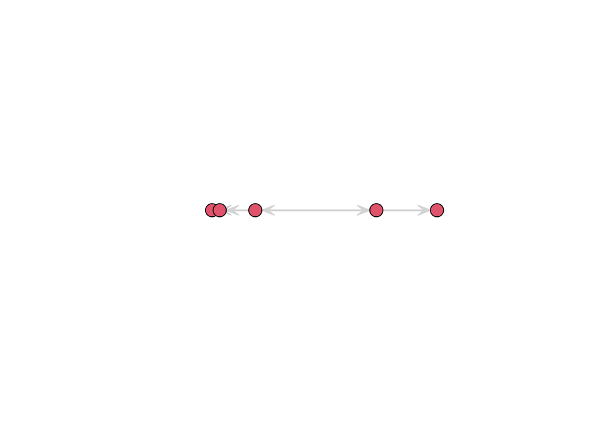

```r
A = cbind(
  c(0, 1, 1, 1, 0),
  c(1, 0, 0, 0, 1),
  c(1, 0, 0, 0, 1),
  c(1, 0, 0, 0, 1),
  c(0, 1, 1, 1, 0)
)

g = as.network(A)
D = dist(g)
Z = cmdscale(D, 2)
gplot(A, coord=Z, edge.col="lightgray")
```

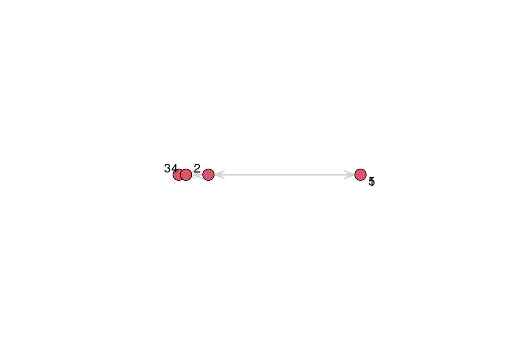

```r
A = cbind(
  c(0, 1, 1, 1),
  c(1, 0, 0, 0),
  c(1, 0, 0, 0),
  c(1, 0, 0, 0)
)

g = as.network(A)
D = dist(g)
Z = cmdscale(D, 2)
gplot(A, coord=Z, edge.col="lightgray", label=1:5)
```

As we see on this quite simple example, MDS can be trapped in some difficult numerical situations and the resulting visualization can become very poor.

## The Latent Space Model

Let’s first try to code ourselves an implementation of the LSM.

```r
negloglik <- function(theta, A, d) {
  # Definition of the log-likelihood to optimize
  ll=0
  n = nrow(A)
  alpha = theta[1]
  Z = matrix(theta[-1], ncol=d)
  D = as.matrix(dist(Z))
  for (i in 1:(n-1)) {
    for (j in (i+1):n) {
      ll = ll + A[i,j] * (alpha - D[i,j]) - log(1+exp(alpha - D[i,j]))
    }
  }
  ll = -2*ll # to account all the symmetric values
  ll
}

LSM <- function(A, d, ...) {
  # A: Adjacency Matrix, denoted by X in the math
  # Y: covariate (could be null)
  # d: latent space (2 by default)
  # initializes values for theta
  n = nrow(A)
  alpha_0 = 0.5
  Z_0 = rnorm(n*d, 0, 1)
  theta = c(alpha_0, Z_0)
  # numerical optimization TO MODIFY SO IT MAXIMUZES THE LOG-LIKELIHOOD
  theta_opt = optim(theta, negloglik, A=A, d=d,...)
  print(matrix(theta_opt$par, ncol=d))
  print(theta_opt[-1])
  print(theta_opt[1])
  alpha = theta_opt$par[1]
  Z = matrix(theta_opt$par[-1], ncol=d)
  return(list(alpha=alpha, Z=Z))
}
```

Professor’s code:

```r
library(sna)
LSM <- function(A,dim=2,...){
  # A is the adjacency matrix and is denoted by X in the maths,
  # dim is the dimensionality of the latent space (2 by default)
  n = nrow(A)

  # definition of the log-likelihood to optimize
  negloglik <- function(theta,A,dim){
    ll = 0
    alpha = theta[1]
    Z = matrix(theta[-1],ncol=dim)
    D = as.matrix(dist(Z))
    for (i in 1:(n-1)){
      for (j in (i+1):n){
        ll = ll + A[i,j]*(alpha - D[i,j]) - log(1 + exp(alpha - D[i,j]))
      }
    }
    negll = - 2 * ll
  }

  # Initial values for theta
  alpha_0 = 0.5
  Z_0 = rnorm(n*dim,0,1)
  theta = c(alpha_0,Z_0)


  # Numerical optimization
  theta_opt = optim(theta,negloglik,A=A,dim=dim,...)

  # Plot and return the results
  alpha = theta_opt$par[1]
  Z = matrix(theta_opt$par[-1],ncol=dim)
  return(list(alpha=alpha,Z=Z))
}
```

Test:

```r
test = LSM(A, 2)
```

## Exercise

This code won’t work as it is because it contains an error. Modify it such that the function maximizes the log-likelihood and then test it on both the simple network and the sampson monks.

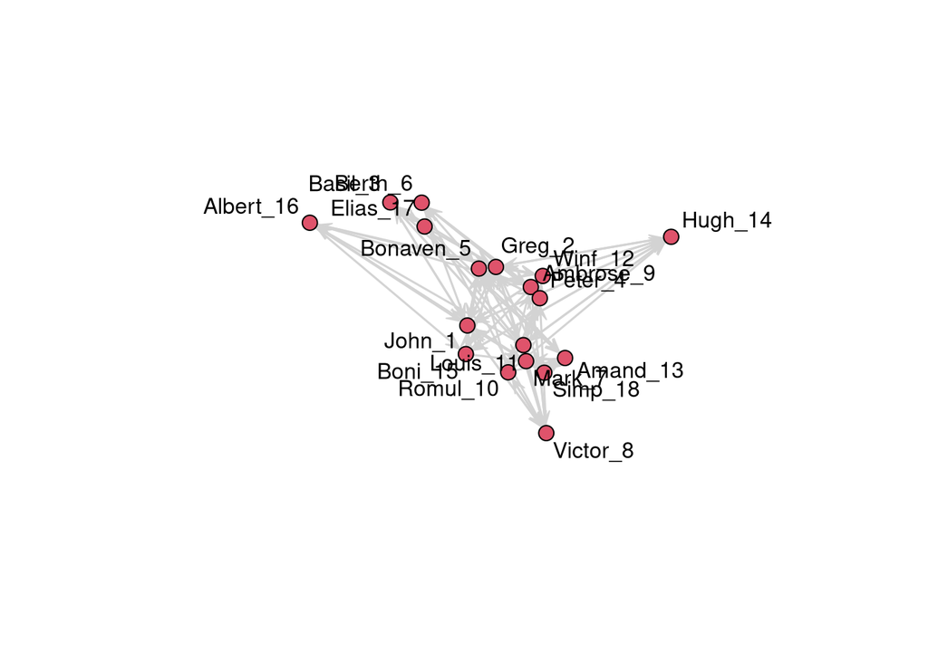

```r
library(VBLPCM)
data(sampson)
A = as.matrix.network.adjacency(samplike)

n = nrow(A)
dim = 2
Z.rand = matrix(rnorm(n*dim, 0, 1), ncol=dim)
out = LSM(A, 2, method = "SANN")
gplot(A, coord=Z.rand, edge.col="lightgray", label = rownames(A))
```

Just to quantify the importance of the work done by LSM in finding relevant positions for plotting the network, we can compare it to a random positionning of the nodes:

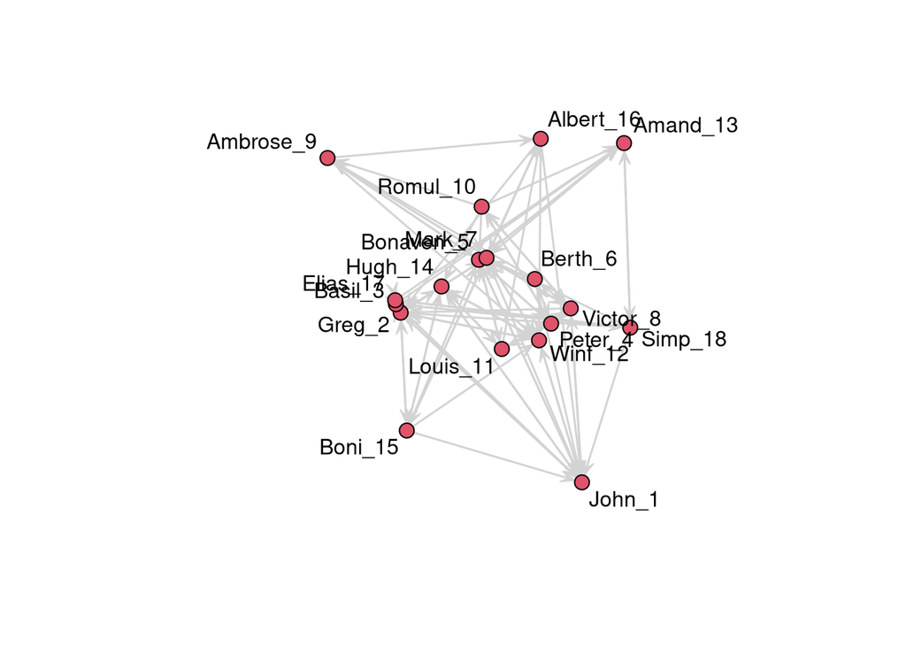

```r
n = nrow(A)
dim = 2
Z.rand = matrix(rnorm(n*dim, 0, 1), ncol=dim)
gplot(A, coord=Z.rand, edge.col="lightgray", label=rownames(A))
```

One of the main interest of the LSM model is its ability to model the uncertainty of the edges we observe or not. We can indeed, once the model parameters estimated, compute the posterior probabilities of the edges to be observed:

$$P(Y_{ij}=1|\hat{\alpha}, \hat{Z})$$

Remember that the model assumes $\mathrm{logit}(P(Y_{ij}=1|\alpha}, Z)) = \alpha - d(z_i, z_j)$ where $\mathrm{logit}(p)=\log(\frac{p}{1-p})$. So, it is quite easy to get the expression of $P(Y_{ij}=1|\alpha,Z)$.

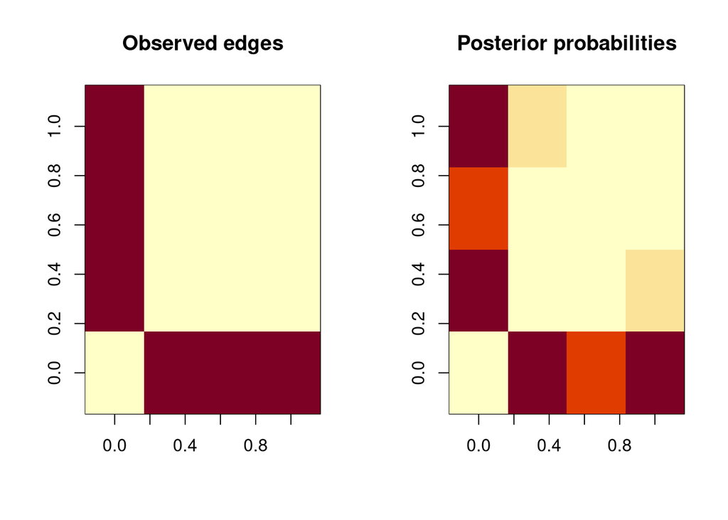

```r
LSM.posterior <- function(out) {
  n = nrow(out$Z)
  P = matrix(0, n, n)
  D = as.matrix(dist(out$Z))
  for (i in 1:(n-1)){
    for (j in (i+1):n){
      P[i,j] = P[j,i] = exp(out$a - D[i,j]) / (1+exp(out$a - D[i,j]))
    }
  }
  return(P)
}

A = cbind(
  c(0, 1, 1, 1),
  c(1, 0, 0, 0),
  c(1, 0, 0, 0),
  c(1, 0, 0, 0)
)

out = LSM(A, dim=2, method="SANN")
P = LSM.posterior(out)
par(mfrow=c(1,2))
image(A, main="Observed edges")
image(P, main="Posterior probabilities")
```

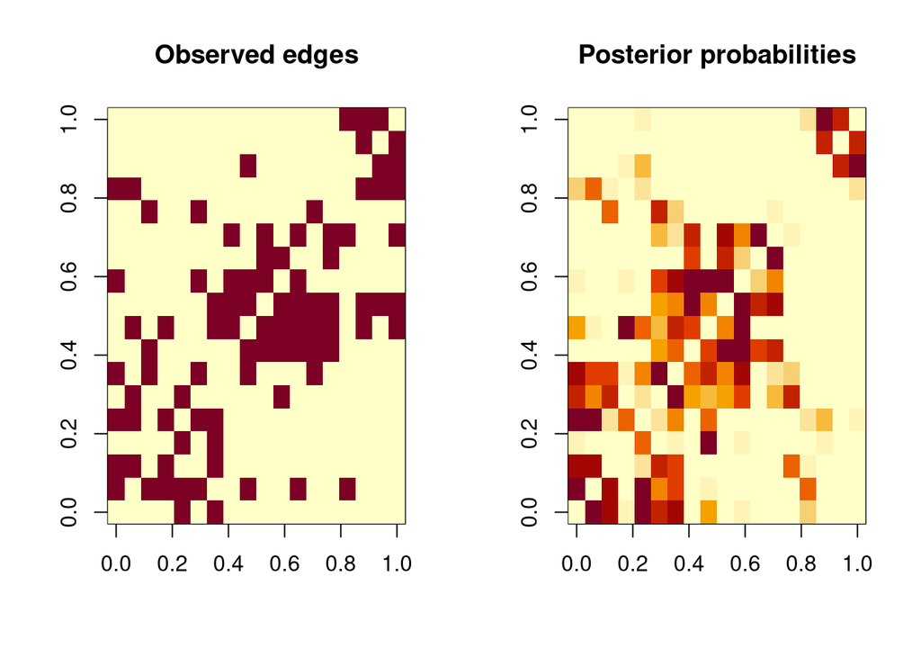

```r
data(sampson)
A = as.matrix.network.adjacency(samplike)
out = LSM(A, dim=2, method="SANN")
P = LSM.posterior(out)

par(mfrow=c(1,2))
image(A, main="Observed edges")
image(P, main="Posterior probabilities")
```

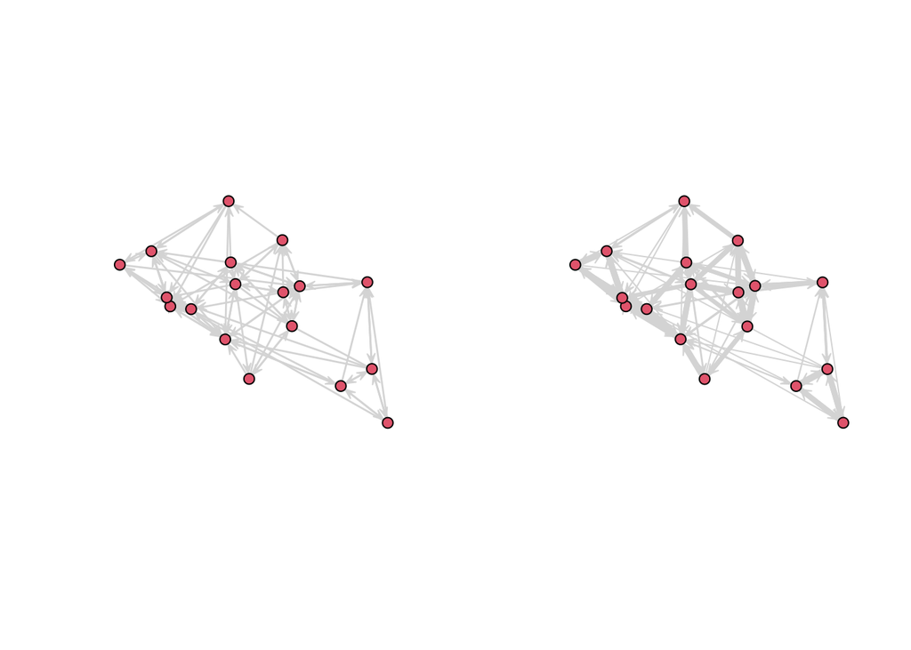

```r
par(mfrow=c(1,2))
gplot(A, coord=out$Z, edge.col="lightgray")
gplot(A, coord=out$Z, edge.col="lightgray", edge.lwd=10*P)
```